Análisis de datos · Pruebas Saber Pro 2023 · Región Caribe

# Desigualdad socioeconómica y *rendimiento académico* en el Caribe colombiano

Un análisis estadístico multivariado de 131.184 estudiantes de educación superior, explorando cómo las condiciones del hogar, el capital educativo familiar y los recursos materiales predicen el desempeño en las Pruebas Saber Pro.

131.184Estudiantes analizados

46Variables analizadas

8Métodos estadísticos

6Módulos Saber Pro

Explorar

01 — Diseño del estudio

## Metodología estadística

El análisis parte de los microdatos oficiales del ICFES para la aplicación **2023** de las Pruebas Saber Pro en la **Región Caribe**. Se construyeron variables ordinales codificadas a partir de respuestas categóricas, y se aplicó una batería de técnicas estadísticas complementarias para capturar tanto la magnitud como la robustez de las asociaciones.

Correlación de Spearman (ρ) Correlación de Pearson (r) T-test de Student d de Cohen Regresión OLS múltiple Coeficientes β estandarizados Intervalos de confianza 95% Pruebas de significancia (p)

9

Variables socioeconómicas

Estrato de vivienda, educación de padre y madre, valor de matrícula, NSE individual, acceso a internet, computador, automóvil y horas de trabajo semanal.

6

Módulos de rendimiento

Puntaje Global, Razonamiento Cuantitativo, Lectura Crítica, Competencias Ciudadanas, Inglés y Comunicación Escrita.

ρ

Estadístico principal

Se priorizó Spearman por ser más robusto ante la naturaleza ordinal de las variables socioeconómicas y la presencia de observaciones extremas en los puntajes.

02 — Visión global

## Matriz de correlaciones

FIG 01 Matriz de correlaciones de Spearman — Variables socioeconómicas × Rendimiento académico

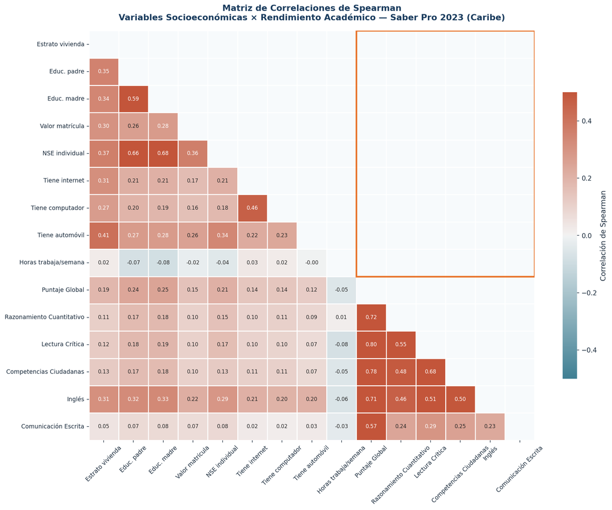

### Resumen de correlaciones clave

[output not shown]

03 — Estratificación

## Estrato socioeconómico y rendimiento

El estrato de vivienda, como proxy clásico del nivel socioeconómico en Colombia, muestra una asociación positiva y estadísticamente significativa con todos los módulos de las Saber Pro. La brecha entre estratos bajos y altos es más pronunciada en el módulo de **Inglés**, lo que sugiere que el acceso a formación complementaria en idiomas está fuertemente condicionado por el entorno económico.

FIG 02 Distribución de puntajes por estrato socioeconómico — todos los módulos

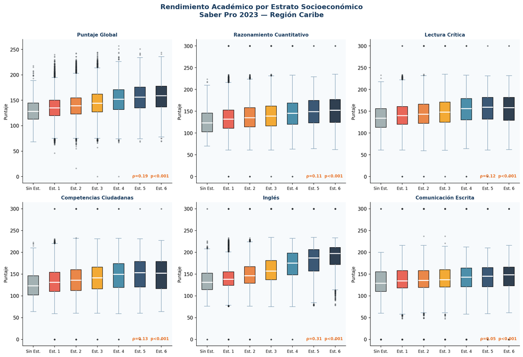

— Estimación basada en medianas por grupo, Saber Pro 2023 Caribe · n=131.184

04 — Capital educativo familiar

## Educación de los padres como predictor académico

La escolaridad del padre y, especialmente, de la madre, constituyen los predictores socioeconómicos individuales más potentes del rendimiento. Esto es coherente con la teoría del capital cultural de Bourdieu: el ambiente intelectual del hogar, las expectativas académicas y las habilidades cognitivas transmitidas entre generaciones actúan como facilitadores del aprendizaje.

FIG 03 Distribución del Puntaje Global según nivel educativo del padre y la madre

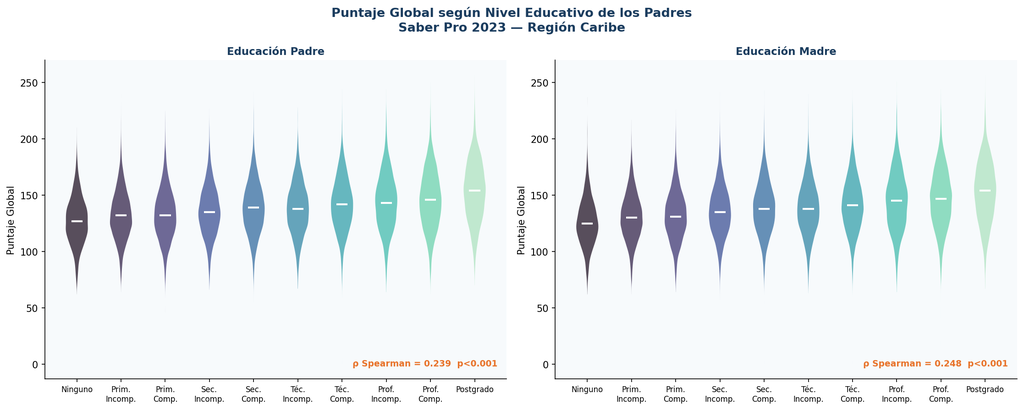

### ¿Por qué la educación materna tiene más peso?

La literatura educativa latinoamericana indica que en contextos de alta desigualdad, la madre es frecuentemente la figura que supervisa las tareas, mantiene contacto con el colegio y modela hábitos de estudio. Una mayor escolaridad materna amplifica directamente estos comportamientos.

05 — Infraestructura del hogar

## Acceso a recursos tecnológicos y materiales

Contar con internet, computador o automóvil en el hogar no solo refleja el nivel de ingresos, sino que incide directamente en las oportunidades de aprendizaje. Los estudiantes con acceso a internet tienen mayor capacidad para buscar recursos, complementar sus estudios y prepararse para las pruebas.

FIG 04 Diferencia en puntajes según acceso a recursos del hogar — medias con IC 95%

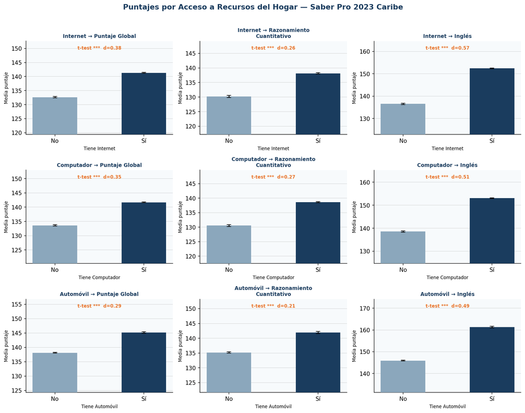

**Cada panel** compara la media del puntaje entre quienes no tienen (azul claro) y tienen (azul oscuro) el recurso indicado. Las barras de error son intervalos de confianza al 95%. Los tamaños del efecto (d de Cohen) y la significancia del t-test aparecen en la parte superior de cada panel. Todos los contrastes son altamente significativos (p < 0.001).

~7–9 pts

Ventaja por acceso a internet

~6–8 pts

Ventaja por tener computador

El acceso a un computador se asocia con una ventaja similar a la del internet, sugiriendo que ambos recursos actúan sinérgicamente en el capital tecnológico del hogar.

d ≈ 0.3

Tamaño del efecto

06 — Carga laboral estudiantil

## Horas de trabajo y rendimiento: una relación negativa

FIG 05 Evolución de puntajes según horas de trabajo semanal — medias con IC 95%

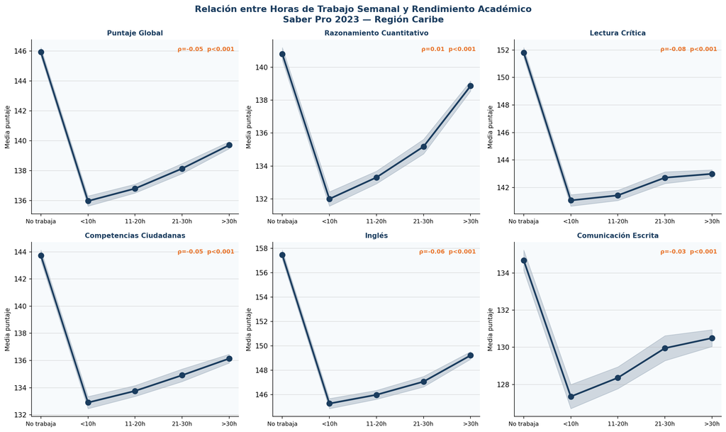

— Análisis de medias por grupo, Saber Pro 2023 Caribe

07 — Índice NSE

## NSE Individual y dispersión del rendimiento

El Índice de Nivel Socioeconómico (NSE) del ICFES sintetiza en un único valor la posición socioeconómica del estudiante. El hexbin a continuación revela la densidad conjunta de valores NSE y puntajes, permitiendo observar tanto la tendencia central como la heterogeneidad dentro de cada nivel.

FIG 06 NSE Individual vs Puntaje Global e Inglés — densidad hexagonal y línea de regresión

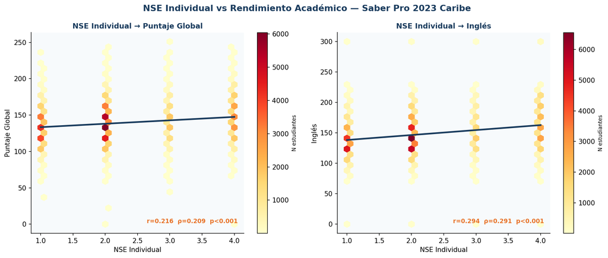

**Cada hexágono** representa un cluster de estudiantes; su color indica la concentración. La línea azul es la tendencia OLS. Las métricas r (Pearson) y ρ (Spearman) confirman que la relación lineal es leve pero robusta y altamente significativa. La gran dispersión vertical en cada nivel NSE sugiere que hay factores no socioeconómicos que también inciden fuertemente en el rendimiento individual.

08 — Comparativa por módulo

## Fortaleza de la correlación por módulo académico

No todos los módulos responden igual a las variables socioeconómicas. El módulo de **Inglés** muestra las correlaciones más altas con casi todas las variables socioeconómicas, mientras que **Comunicación Escrita** y **Competencias Ciudadanas** presentan correlaciones más modestas.

FIG 07 Coeficientes ρ de Spearman por variable socioeconómica y módulo académico

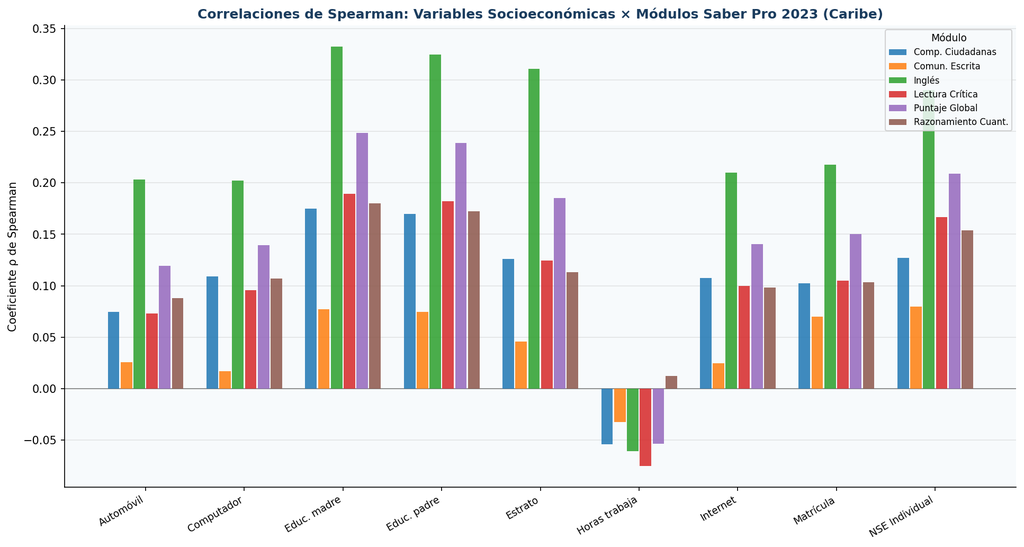

09 — Modelo predictivo

## Regresión múltiple: contribución relativa de cada factor

Para aislar el efecto de cada variable socioeconómica controlando por las demás, se estimó un modelo de regresión lineal múltiple con coeficientes estandarizados (β). Esto permite comparar directamente la magnitud de cada predictor sobre el Puntaje Global.

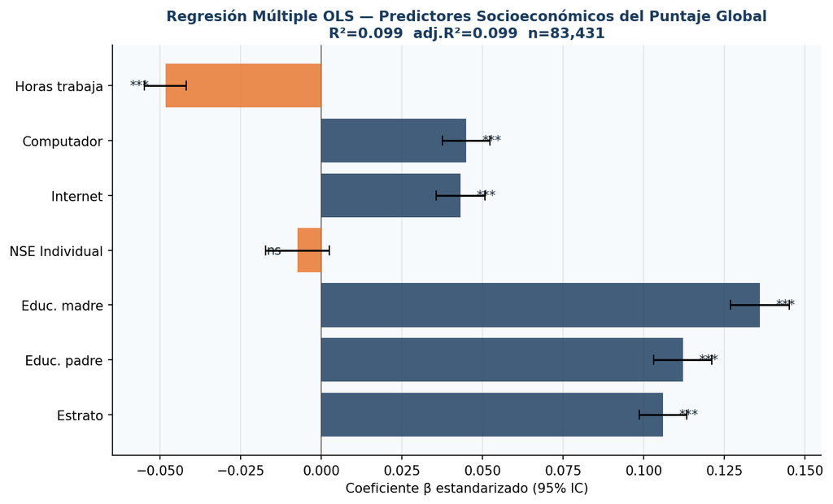

**Las barras azules** indican predictores positivos (mayor valor = mayor puntaje); las naranjas, negativos. Los intervalos de confianza al 95% aparecen como líneas negras. Los asteriscos indican significancia: *** p<0.001, ** p<0.01, * p<0.05, ns = no significativo. La educación materna (β=0.136) y paterna (β=0.112) son los predictores más potentes. Las horas de trabajo (β=−0.048) son el único predictor negativo significativo.

### Resultados del modelo

El modelo explica el **9.9% de la varianza** (R²=0.099) del Puntaje Global. Si bien este porcentaje puede parecer modesto, es consistente con la literatura: los factores socioeconómicos son condicionantes importantes pero no deterministas del rendimiento individual, que también depende de capacidades cognitivas, motivación y calidad institucional.

### Jerarquía de predictores (β estandarizado)

**1°** Educación madre (β=0.136) · **2°** Educación padre (β=0.112) · **3°** Estrato (β=0.106) · **4°** Computador (β=0.045) · **5°** Internet (β=0.043) · **6°** Horas trabajadas (β=−0.048) · NSE individual no significativo al controlar los demás factores.

10 — Hallazgos

## Conclusiones del estudio

El análisis de 131.184 estudiantes de la Región Caribe en las Pruebas Saber Pro 2023 revela un patrón inequívoco: las condiciones socioeconómicas del hogar actúan como facilitadores o restricciones del aprendizaje con efectos sistemáticos y estadísticamente robustos.

📚

#### El capital educativo familiar es el predictor más potente

La educación de la madre (β=0.136) y del padre (β=0.112) superan en influencia al estrato, el NSE y los recursos materiales. El ambiente intelectual del hogar y las expectativas académicas familiares transmiten ventajas cognitivas intergeneracionales que ninguna política de equipamiento tecnológico puede compensar fácilmente.

🌐

💻

#### Los recursos tecnológicos importan, pero no son suficientes

Tener internet y computador en casa se asocia con 7–9 puntos adicionales en el Puntaje Global (d≈0.3). Sin embargo, su efecto en la regresión múltiple (β≈0.04–0.05) es menor que el del capital educativo familiar, lo que sugiere que la conectividad sin acompañamiento pedagógico tiene un impacto limitado.

⏱️

🏘️

#### El estrato reproduce la desigualdad de manera estructural

🎯

#### El modelo explica el 10%, no el todo

Con R²=0.099, las variables socioeconómicas explican cerca del 10% de la varianza del puntaje. Esto implica que el 90% restante obedece a factores individuales (motivación, estrategias de aprendizaje, capacidades), institucionales (calidad del programa, docentes) y de medición. El origen no determina el destino, pero sí lo condiciona significativamente.

Recomendaciones de política pública

Los hallazgos sugieren que las intervenciones más efectivas deberían apuntar a: **(1)** elevar el nivel educativo de los hogares a través de programas de formación para padres en comunidades de estratos bajos; **(2)** implementar becas laborales o subsidios que permitan a los estudiantes de bajos recursos reducir su jornada laboral sin pérdida de ingresos; **(3)** fortalecer programas de inglés en universidades públicas del Caribe con metodologías intensivas y gratuitas; y **(4)** garantizar que el acceso a conectividad vaya acompañado de alfabetización digital y recursos pedagógicos de calidad.

Equipo de investigación

## Autores

Este estudio fue desarrollado como proyecto académico de análisis estadístico en la **Universidad Tecnológica de Bolívar**, explorando las relaciones entre condiciones socioeconómicas y rendimiento en las Pruebas Saber Pro 2023 para la Región Caribe.

DJ

Deiner de Jesús  
González Paredes

Análisis estadístico

SJ

Santiago José  
Cuesta Maza

Análisis estadístico

LE

Luis Eduardo  
Mendoza Angulo

Análisis estadístico

DV

Danna Valentina  
Zuluaga Hernández

Análisis estadístico

VB

Valeria Estefanía  
Berrío Payares

Análisis estadístico